# Understanding User Ratings

Vishal Gupta

5/6/2019

```r
library(dplyr)
library(tidyr)
library(randomForest)
library(rpart)
library(rpart.plot)
library(caret)
library(e1071)
```

#### Problem 1 - Exploratory Data Analysis

Read the dataset ratings.csv into a dataframe called ratings.

How many users are in the dataset?

```r
ratings = read.csv("~/Downloads/ratings.csv")
nrow(ratings)
```

```
## [1] 5456
```

How many categories are rated in the dataset?

```r
dim(ratings)[2]
```

```
## [1] 24
```

Note that there are some NA’s in the data. Which columns have missing data?

```r
summary(ratings)
```

```
##        userid        churches        resorts         beaches
##  User 1   :   1   Min.   :0.000   Min.   :0.000   Min.   :0.000
##  User 10  :   1   1st Qu.:0.920   1st Qu.:1.360   1st Qu.:1.540
##  User 100 :   1   Median :1.340   Median :1.905   Median :2.060
##  User 1000:   1   Mean   :1.456   Mean   :2.320   Mean   :2.489
##  User 1001:   1   3rd Qu.:1.810   3rd Qu.:2.683   3rd Qu.:2.740
##  User 1002:   1   Max.   :5.000   Max.   :5.000   Max.   :5.000
##  (Other)  :5450
##      parks          theatres        museums          malls
##  Min.   :0.830   Min.   :1.120   Min.   :1.110   Min.   :1.120
##  1st Qu.:1.730   1st Qu.:1.770   1st Qu.:1.790   1st Qu.:1.930
##  Median :2.460   Median :2.670   Median :2.680   Median :3.230
##  Mean   :2.797   Mean   :2.959   Mean   :2.893   Mean   :3.351
##  3rd Qu.:4.093   3rd Qu.:4.312   3rd Qu.:3.840   3rd Qu.:5.000
##  Max.   :5.000   Max.   :5.000   Max.   :5.000   Max.   :5.000
##
##       zoo         restaurants         pubs        burger_shops
##  Min.   :0.860   Min.   :0.840   Min.   :0.810   Min.   :0.780
##  1st Qu.:1.620   1st Qu.:1.800   1st Qu.:1.640   1st Qu.:1.290
##  Median :2.170   Median :2.800   Median :2.680   Median :1.690
##  Mean   :2.541   Mean   :3.126   Mean   :2.833   Mean   :2.078
##  3rd Qu.:3.190   3rd Qu.:5.000   3rd Qu.:3.530   3rd Qu.:2.285
##  Max.   :5.000   Max.   :5.000   Max.   :5.000   Max.   :5.000
##                                                  NA's   :1
##      hotels        juice_bars    art_galleries    dance_clubs
##  Min.   :0.770   Min.   :0.760   Min.   :0.000   Min.   :0.000
##  1st Qu.:1.190   1st Qu.:1.030   1st Qu.:0.860   1st Qu.:0.690
##  Median :1.610   Median :1.490   Median :1.330   Median :0.800
##  Mean   :2.126   Mean   :2.191   Mean   :2.207   Mean   :1.193
##  3rd Qu.:2.360   3rd Qu.:2.740   3rd Qu.:4.440   3rd Qu.:1.160
##  Max.   :5.000   Max.   :5.000   Max.   :5.000   Max.   :5.000
##
##      pools             gyms           bakeries           spas
##  Min.   :0.0000   Min.   :0.0000   Min.   :0.0000   Min.   :0.00
##  1st Qu.:0.5800   1st Qu.:0.5300   1st Qu.:0.5200   1st Qu.:0.54
##  Median :0.7400   Median :0.6900   Median :0.6900   Median :0.69
##  Mean   :0.9492   Mean   :0.8224   Mean   :0.9698   Mean   :1.00
##  3rd Qu.:0.9100   3rd Qu.:0.8400   3rd Qu.:0.8600   3rd Qu.:0.86
##  Max.   :5.0000   Max.   :5.0000   Max.   :5.0000   Max.   :5.00
##
##      cafes         view_points      monuments        gardens
##  Min.   :0.0000   Min.   :0.000   Min.   :0.000   Min.   :0.000
##  1st Qu.:0.5700   1st Qu.:0.740   1st Qu.:0.790   1st Qu.:0.880
##  Median :0.7600   Median :1.030   Median :1.070   Median :1.290
##  Mean   :0.9658   Mean   :1.751   Mean   :1.531   Mean   :1.561
##  3rd Qu.:1.0000   3rd Qu.:2.070   3rd Qu.:1.560   3rd Qu.:1.660
##  Max.   :5.0000   Max.   :5.000   Max.   :5.000   Max.   :5.000
##                                                   NA's   :1
```

- resorts
- parks
- museums
- malls
- restaurants
- **burger_shops**
- juice_bars
- dance_clubs
- bakeries
- cafes
- **gardens**

What will happen if NA values are replaced with the value 0?

- **Categories with missing values will be penalized.**
- Categories with missing values will be rewarded.
- The dataset and task will not be affected. This is the most fair way to handle the missing values.

To deal with the missing values, we will simply remove the observations with the missing values first (there are more sophisticated ways to work with missing values, but for this purpose removing the observations is fine since we do not lose a significant amount of observations). Run the following code:

```r
ratings = ratings[rowSums(is.na(ratings)) == 0, ]
```

How many users are there now?

```r
nrow(ratings)
```

```
## [1] 5454
```

Which category has the highest mean score?

- resorts
- beaches
- theatres
- **malls**
- juice_bars
- drama
- hotels
- gyms

#### Problem 2 - Preparing the Data

Before performing clustering on the dataset, which variable(s) should be removed?

- gyms
- **userid**
- burger_shops and gardens

Remove the necessary column from the dataset and rename the new data frame points.

```r
points = ratings[2:24]
```

Now, we will normalize the data.

What will the maximum value of pubs be after applying mean-var normalization? Answer without actually normalizing the data.

Normalize the data using the following code:

```r
library(caret)
preproc = preProcess(points)
pointsnorm = predict(preproc, points)
```

What is the maximum value of juice_bars after the normalization?

```r
summary(pointsnorm$juice_bars)
```

```
##    Min. 1st Qu.  Median    Mean 3rd Qu.    Max.
## -0.9073 -0.7361 -0.4443  0.0000  0.3486  1.7822
```

#### Problem 3.1 - Clustering

Create a dendogram using the following code:

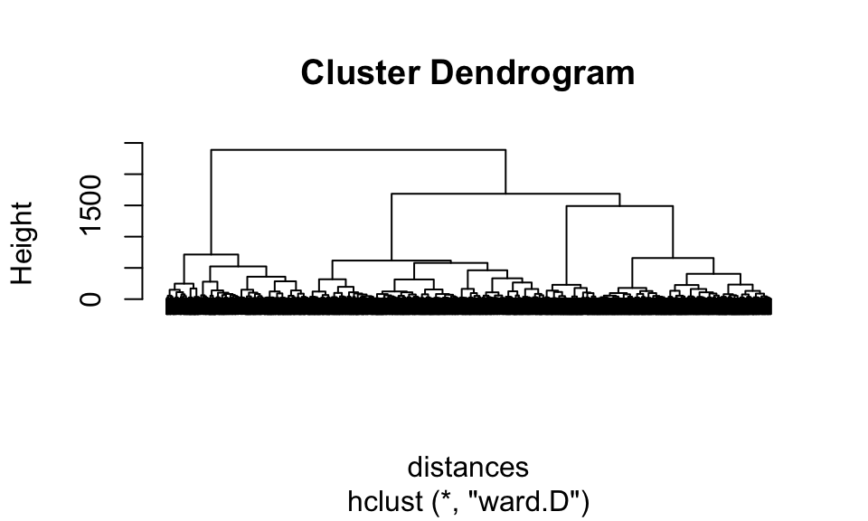

```r
distances = dist(pointsnorm, method = "euclidean")
dend = hclust(distances, method = "ward.D")
plot(dend, labels = FALSE)
```

Based on the dendrogram, how many clusters do you think would NOT be appropriate for this problem?

- 2
- 3
- 4
- **5**

Based on this dendogram, in choosing the number of clusters, what is the best option?

**4**

#### Problem 3.2 - Clustering

Set the random seed to 100, and run the k-means clustering algorithm on your normalized dataset, setting the number of clusters to 4.

```r
set.seed(100)
```

How many observations are in the largest cluster?

```r
userKmeans = kmeans(pointsnorm,4)
max(table(as.factor(userKmeans$cluster)))
```

```
## [1] 1996
```

#### Problem 4 - Conceptual Questions

True or False: If we ran k-means clustering a second time without making any additional calls to set.seed, we would expect every observation to be in the same cluster as it is now.

- True
- **False**

True or False: K-means clustering is sensative to outliers.

- **True**
- False

Why do we typically use cluster centroids to describe the clusters?

- The cluster centroid gives the values of every single observation in the cluster, and therefore exactly describes the cluster.
- **The cluster centroid captures the average behavior in the cluster, and can be used to summarize the general pattern in the cluster.**
- The cluster centroid captures the average behavior in the cluster, relative to the other clusters. So by just computing a single cluster centroid, we can understand how the cluster differs from the other clusters.

Is “overfitting” a problem in clustering?

- No, we don’t have test data, so it is impossible to evaluate k-means out-of-sample
- **Yes, at the extreme every data point can be assigned to its own cluster.**
- It depends on the application.

Is “multicollinearity” a problem in clustering?

- No, because we aren’t trying to find coefficients in our model.
- **Yes, multicollinearity could cause certain features to be overweighted in the distances calculations.**
- It depends on the application.

#### Problem 5 - Understanding the Clusters

Which cluster has the user with the lowest average rating in restaurants?

```r
userKmeans$cluster[which.min(pointsnorm$restaurants)]
```

```
## 2807
##    4
```

- Cluster 1
- Cluster 2
- Cluster 3
- **Cluster 4**

Which of the clusters is best described as “users who have mostly enjoyed churches, pools, gyms, bakeries, and cafes”?

```r
summary(userKmeans$centers)
```

```
##     churches           resorts            beaches            parks
##  Min.   :-0.88917   Min.   :-0.91569   Min.   :-0.6698   Min.   :-0.8824
##  1st Qu.:-0.47433   1st Qu.:-0.28224   1st Qu.:-0.4892   1st Qu.:-0.5806
##  Median :-0.14005   Median : 0.05859   Median :-0.2541   Median :-0.4692
##  Mean   :-0.02206   Mean   :-0.13668   Mean   :-0.1333   Mean   :-0.2219
##  3rd Qu.: 0.31221   3rd Qu.: 0.20415   3rd Qu.: 0.1018   3rd Qu.:-0.1106
##  Max.   : 1.08101   Max.   : 0.25179   Max.   : 0.6449   Max.   : 0.9331
##     theatres           museums            malls
##  Min.   :-0.92590   Min.   :-0.8874   Min.   :-0.93718
##  1st Qu.:-0.74921   1st Qu.:-0.8249   1st Qu.:-0.40000
##  Median :-0.52737   Median :-0.3171   Median :-0.15169
##  Mean   :-0.25497   Mean   :-0.2548   Mean   :-0.14850
##  3rd Qu.:-0.03313   3rd Qu.: 0.2530   3rd Qu.: 0.09982
##  Max.   : 0.96078   Max.   : 0.5023   Max.   : 0.64657
##       zoo            restaurants            pubs
##  Min.   :-0.84500   Min.   :-0.97186   Min.   :-0.89339
##  1st Qu.:-0.58196   1st Qu.:-0.50473   1st Qu.:-0.39034
##  Median :-0.35765   Median :-0.27467   Median :-0.08415
##  Mean   :-0.18159   Mean   :-0.14493   Mean   :-0.09435
##  3rd Qu.: 0.04271   3rd Qu.: 0.08513   3rd Qu.: 0.21184
##  Max.   : 0.83393   Max.   : 0.94147   Max.   : 0.68430
##   burger_shops         hotels          juice_bars       art_galleries
##  Min.   :-0.4782   Min.   :-0.3856   Min.   :-0.40924   Min.   :-0.47024
##  1st Qu.:-0.2330   1st Qu.:-0.2256   1st Qu.:-0.20740   1st Qu.:-0.02222
##  Median :-0.1297   Median :-0.1506   Median :-0.07388   Median : 0.12746
##  Mean   : 0.2180   Mean   : 0.2246   Mean   : 0.26145   Mean   : 0.18422
##  3rd Qu.: 0.3212   3rd Qu.: 0.2995   3rd Qu.: 0.39497   3rd Qu.: 0.33390
##  Max.   : 1.6097   Max.   : 1.5852   Max.   : 1.60280   Max.   : 0.95222
##   dance_clubs           pools              gyms            bakeries
##  Min.   :-0.23674   Min.   :-0.3109   Min.   :-0.3187   Min.   :-0.35733
##  1st Qu.:-0.10625   1st Qu.:-0.2390   1st Qu.:-0.2898   1st Qu.:-0.29752
##  Median :-0.05081   Median :-0.1357   Median :-0.1105   Median :-0.02552
##  Mean   : 0.06717   Mean   : 0.1223   Mean   : 0.1521   Mean   : 0.17629
##  3rd Qu.: 0.12261   3rd Qu.: 0.2257   3rd Qu.: 0.3314   3rd Qu.: 0.44829
##  Max.   : 0.60705   Max.   : 1.0714   Max.   : 1.1479   Max.   : 1.11355
##       spas              cafes          view_points
##  Min.   :-0.30272   Min.   :-0.3553   Min.   :-0.68804
##  1st Qu.:-0.18730   1st Qu.:-0.2957   1st Qu.:-0.49936
##  Median :-0.07596   Median :-0.2062   Median :-0.05813
##  Mean   : 0.10823   Mean   : 0.0652   Mean   :-0.04865
##  3rd Qu.: 0.21957   3rd Qu.: 0.1547   3rd Qu.: 0.39258
##  Max.   : 0.88755   Max.   : 1.0284   Max.   : 0.60970
##    monuments           gardens
##  Min.   :-0.70138   Min.   :-0.72216
##  1st Qu.:-0.49151   1st Qu.:-0.44417
##  Median :-0.07730   Median :-0.11988
##  Mean   :-0.03947   Mean   :-0.01711
##  3rd Qu.: 0.37474   3rd Qu.: 0.30718
##  Max.   : 0.69811   Max.   : 0.89348
```

- **Cluster 1**
- Cluster 2
- Cluster 3
- Cluster 4

Which cluster seems to enjoy being outside, but does not enjoy as much going to the zoo or pool?

- Cluster 1
- Cluster 2
- Cluster 3
- **Cluster 4**